# Point of View & Perspective Taking

Kathryn Denning

March 23, 2020

# Introduction to study

This study looked at whether the point of view people responded in when writing about the day in the life of a target individual (e.g., a perspective taking manipulation) impacted the extent they projected (Analysis 1) and stereotyped (Analysis 2) with the target individual. We also checked to see if the point of view condition predicted self-reported perspective taking by participants (Analysis 3). Due to an issue with singularity in our MLM in Analysis 1, we also analyzed difference scores in projection as the outcome variable, instead of item level scores for projection (see difference score results in Analysis 4).

Variable names that might be confusing:

- **pt_condition** : What perpsective taking condition participants were randomly assigned. Helmert contrasts were applied to this variable.
  - 1 = 1st person
  - 2 = 3rd person
  - 3 = Control
  - 4 = Objective
- **targ** : Participants’ responses for the target on the BFI.
- **self_c** : Participants’ responses for themselves on the BFI. This variable was mean-centered.
- **pt_mancheck** : Participants’ self-reported responses on how much they took the perspective of the target. This was coded as follows, but reverse coded for the plot in Analysis 3 to make it more interpretable (that higher scores meant more PT).
  - 1 = A great deal
  - 2 = A lot
  - 3 = A moderate amount
  - 4 = A little
  - 5 = None at all
- **diff_score** : The difference in the avarage scores of participants’ on the BFI for themselves minus the BFI for the target. These scores were not absolute valued.

# Alpha for the ageism scale so it can be collapse into one composite score per participant

```
## $sample.size
## [1] 442
##
## $number.of.items
## [1] 10
##
## $alpha
## [1] 0.7372717
```

# Demographics

## Sample Size

```r
pov_clean %>%
  select(subid) %>%
  unique() %>%
  na.omit() %>%
  nrow()
```

```
## [1] 439
```

## Participants per condition

```r
pov_clean %>%
  select(subid, pt_condition) %>%
  unique() %>%
  na.omit() %>%
  group_by(pt_condition) %>%
  count()
```

```
## # A tibble: 4 x 2
## # Groups:   pt_condition [4]
##   pt_condition     n
##   <fct>        <int>
## 1 1st             93
## 2 3rd            110
## 3 control         98
## 4 obj            138
```

## Age

### Mean

```r
mean(pov_clean$age)
```

```
## [1] 19.62482
```

### SD

```r
sd(pov_clean$age)
```

```
## [1] 3.000891
```

## Gender

```r
pov_clean %>%
  select(subid, gender) %>%
  unique() %>%
  na.omit() %>%
  group_by(gender) %>%
  count()
```

```
## # A tibble: 4 x 2
## # Groups:   gender [4]
##   gender                n
##   <fct>             <int>
## 1 Female              182
## 2 Male                253
## 3 Non-binary            3
## 4 Prefer not to say     1
```

## Race

```r
pov_clean %>%
  select(subid, race) %>%
  unique() %>%
  na.omit() %>%
  group_by(race) %>%
  count() %>%
  mutate(percent = n/439*100)
```

```
## # A tibble: 9 x 3
## # Groups:   race [9]
##   race                              n percent
##   <fct>                         <int>   <dbl>
## 1 American Indian/Alaska Native     2   0.456
## 2 Asian                            46  10.5
## 3 Black                            12   2.73
## 4 Latinx                           24   5.47
## 5 Middle Eastern                    3   0.683
## 6 Other                            19   4.33
## 7 Pacific Islander                 21   4.78
## 8 Prefer not to answer              3   0.683
## 9 White                           309  70.4
```

# Descriptives

## Histogram of distributions

### BFI for Self

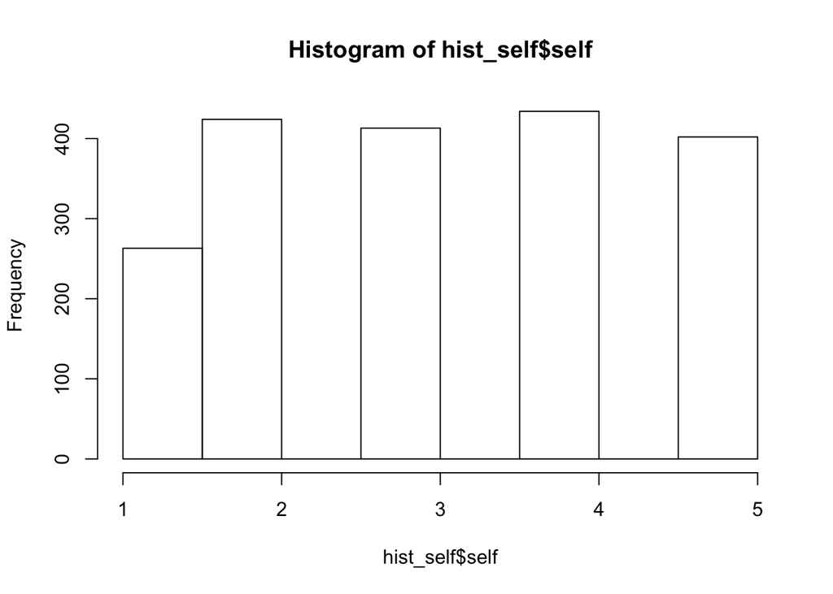

```r
hist_self <- pov_clean %>%
  select(subid, self) %>%
  unique()
hist(hist_self$self)
```

### BFI for Target

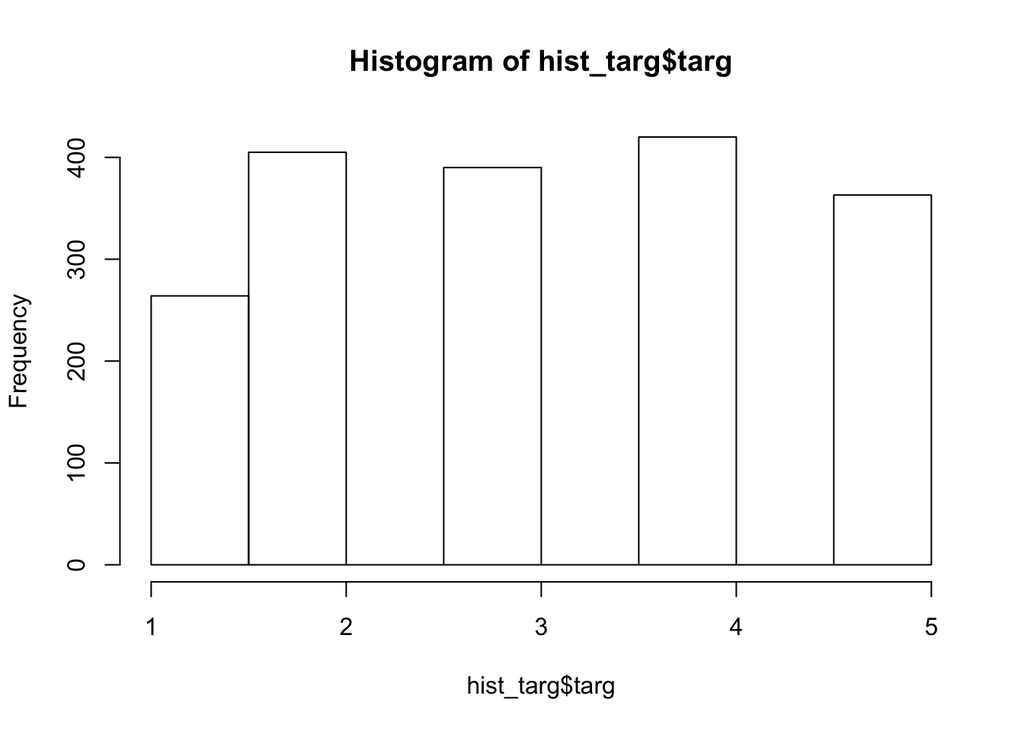

```r
hist_targ <- pov_clean %>%
  select(subid, targ) %>%
  unique()
hist(hist_targ$targ)
```

## Histogram for PT manipulation check

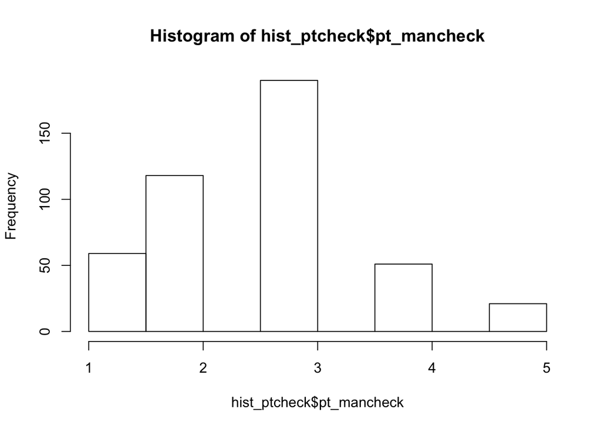

```r
hist_ptcheck <- pov_clean %>%
  select(subid, pt_mancheck) %>%
  mutate(pt_mancheck = as.numeric(pt_mancheck)) %>%
  unique()
hist(hist_ptcheck$pt_mancheck)
```

1 = A great deal 2 = A lot 3 = A moderate amount 4 = A little 5 = None at all

So, people are skewed toward reporting they were perspective taking, which generally they should be based on the instructions

## Histogram for ageism scale

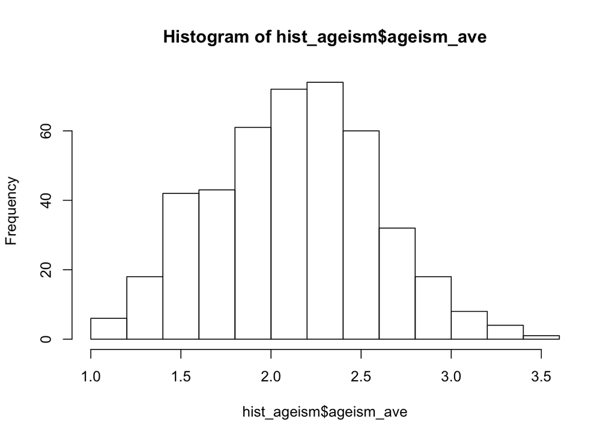

```r
hist_ageism <- pov_clean %>%
  select(subid, ageism_ave) %>%
  unique()
hist(hist_ageism$ageism_ave)
```

## Checking level 1 heteroscedasticity

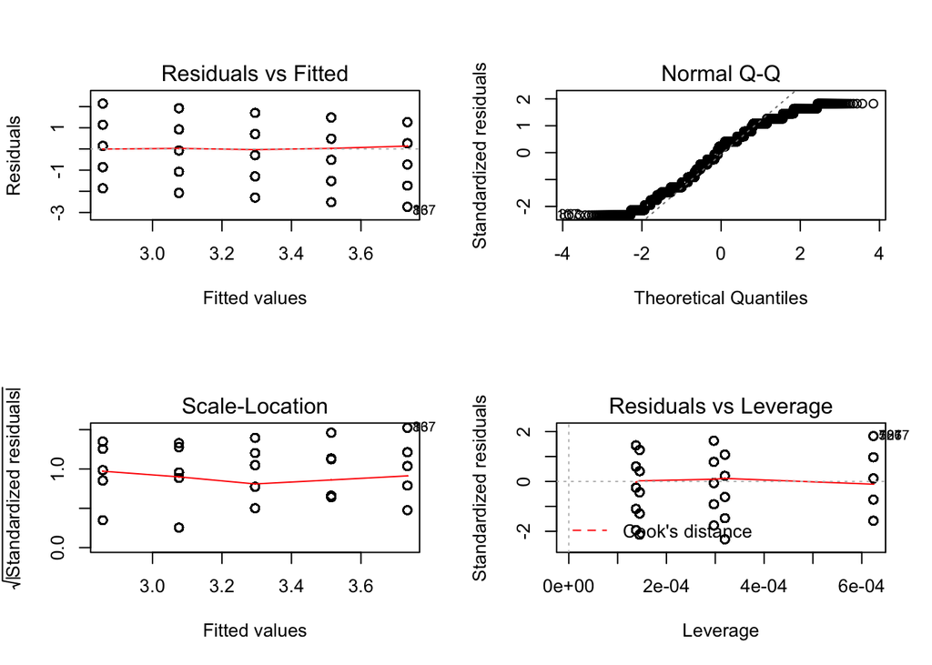

```r
hetero <- lm(targ ~ self, data = pov_clean)
par(mfrow=c(2,2)) # init 4 charts in 1 panel
plot(hetero)
```

Flat line in residuals vs fitted looks good!

## Mean and SD for BFI by PT condition

### BFI for Self

```r
pov_clean %>%
  select(subid, pt_condition, self) %>%
  na.omit() %>%
  group_by(pt_condition) %>%
  summarize(mean = mean(self),
            sd = sd(self))
```

```
## # A tibble: 4 x 3
##   pt_condition  mean    sd
##   <fct>        <dbl> <dbl>
## 1 1st           3.52  1.20
## 2 3rd           3.49  1.20
## 3 control       3.40  1.22
## 4 obj           3.43  1.19
```

### BFI for Target

```r
pov_clean %>%
  select(subid, pt_condition, targ) %>%
  na.omit() %>%
  group_by(pt_condition) %>%
  summarize(mean = mean(targ),
            sd = sd(targ))
```

```
## # A tibble: 4 x 3
##   pt_condition  mean    sd
##   <fct>        <dbl> <dbl>
## 1 1st           3.45  1.22
## 2 3rd           3.40  1.22
## 3 control       3.36  1.20
## 4 obj           3.38  1.20
```

## Mean and SD for ageism by condition

```r
ageism_descrip <- pov_clean %>%
  select(subid, pt_condition, ageism_ave) %>%
  na.omit() %>%
  group_by(pt_condition) %>%
  summarize(mean = mean(ageism_ave),
            sd = sd(ageism_ave),
            se = sd(ageism_ave)/sqrt(length(ageism_ave)))
ageism_descrip
```

```
## # A tibble: 4 x 4
##   pt_condition  mean    sd      se
##   <fct>        <dbl> <dbl>   <dbl>
## 1 1st           2.14 0.427 0.0102
## 2 3rd           2.14 0.461 0.0101
## 3 control       2.23 0.491 0.0114
## 4 obj           2.19 0.453 0.00887
```

## Overall descriptives

```r
pov_clean %>%
  select(age, gender, race, pt_mancheck, self, targ,
         pt_condition, self_c, ageism_ave) %>%
  describe()
```

```
##               vars    n   mean     sd median trimmed    mad   min    max range
## subid            1 8316 232.09 135.04 232.00  231.87 173.46  1.00 467.00 466.0
## age              2 8316  19.62   3.00  19.00   19.11   1.48 18.00  51.00  33.0
## gender*          3 8316   1.60   0.52   2.00    1.61   0.00  1.00   4.00   3.0
## race*            4 8316   7.53   2.51   9.00    8.05   0.00  1.00   9.00   8.0
## pt_mancheck      5 8316   2.67   1.00   3.00    2.66   1.48  1.00   5.00   4.0
## self             6 8316   3.46   1.20   4.00    3.52   1.48  1.00   5.00   4.0
## targ             7 8316   3.40   1.21   4.00    3.45   1.48  1.00   5.00   4.0
## pt_condition*    8 8316   2.64   1.13   3.00    2.67   1.48  1.00   4.00   3.0
## self_c           9 8316   0.00   1.20   0.55    0.07   1.48 -2.45   1.55   4.0
## ageism_ave      10 8316   2.18   0.46   2.20    2.17   0.44  1.00   3.50   2.5
##                skew kurtosis   se
## subid          0.01    -1.22 1.48
## age            6.34    53.08 0.03
## gender*        0.00    -0.63 0.01
## race*         -1.39     0.26 0.03
## pt_mancheck    0.17    -0.17 0.01
## self          -0.37    -0.88 0.01
## targ          -0.31    -0.94 0.01
## pt_condition* -0.14    -1.39 0.01
## self_c        -0.37    -0.88 0.01
## ageism_ave     0.07    -0.28 0.01
```

Only variable that is skewed is age due to an outlier of an older participant.

# Analysis 1: MLM model for projection

## Complex random effects model we predicted

```r
proj_model <- pov_clean %>%
  select(targ, self_c, pt_condition, subid) %>%
  unique() %>%
  na.omit()

contrasts(proj_model$pt_condition) <- "contr.helmert"
contrasts(proj_model$pt_condition)
```

```
##         [,1] [,2] [,3]
## 1st       -1   -1   -1
## 3rd        1   -1   -1
## control    0    2   -1
## obj        0    0    3
```

```r
projection <- lmer(targ ~ self_c*pt_condition + (self_c|subid), data = proj_model)
summary(projection)
```

```
## Linear mixed model fit by REML ['lmerMod']
## Formula: targ ~ self_c * pt_condition + (self_c | subid)
##    Data: proj_model
##
## REML criterion at convergence: 14835.4
##
## Scaled residuals:
##      Min       1Q   Median       3Q      Max
## -2.04070 -0.86189 -0.03892  0.74751  1.67499
##
## Random effects:
##  Groups   Name        Variance  Std.Dev.  Corr
##  subid    (Intercept) 0.000e+00 0.000e+00
##           self_c      1.014e-19 3.185e-10  NaN
##  Residual             1.573e+00 1.254e+00
## Number of obs: 4495, groups:  subid, 439
##
## Fixed effects:
##                        Estimate Std. Error t value
## (Intercept)           3.2651341  0.0190962 170.984
## self_c                0.1447971  0.0149799   9.666
## pt_condition1        -0.0080570  0.0278706  -0.289
## pt_condition2        -0.0310774  0.0163255  -1.904
## pt_condition3        -0.0082158  0.0100966  -0.814
## self_c:pt_condition1  0.0007174  0.0218760   0.033
## self_c:pt_condition2 -0.0110319  0.0127941  -0.862
## self_c:pt_condition3 -0.0042987  0.0079243  -0.542
##
## Correlation of Fixed Effects:
##             (Intr) self_c pt_cn1 pt_cn2 pt_cn3 sl_:_1 sl_:_2
## self_c       0.118
## pt_conditn1 -0.062 -0.005
## pt_conditn2  0.018  0.019  0.048
## pt_conditn3 -0.153 -0.017  0.039 -0.012
## slf_c:pt_c1 -0.005 -0.062  0.105  0.004  0.003
## slf_c:pt_c2  0.019  0.016  0.004  0.131 -0.012  0.049
## slf_c:pt_c3 -0.017 -0.152  0.003 -0.012  0.119  0.039 -0.010
## convergence code: 0
## boundary (singular) fit: see ?isSingular
```

```r
tab_model(projection)
```

|  | targ |  |  |
| --- | --- | --- | --- |
| Predictors | Estimates | CI | p |
| (Intercept) | 3.27 | 3.23 – 3.30 | **<0.001** |
| self_c | 0.14 | 0.12 – 0.17 | **<0.001** |
| pt_condition1 | -0.01 | -0.06 – 0.05 | 0.773 |
| pt_condition2 | -0.03 | -0.06 – 0.00 | 0.057 |
| pt_condition3 | -0.01 | -0.03 – 0.01 | 0.416 |
| self_c : pt_condition1 | 0.00 | -0.04 – 0.04 | 0.974 |
| self_c : pt_condition2 | -0.01 | -0.04 – 0.01 | 0.389 |
| self_c : pt_condition3 | -0.00 | -0.02 – 0.01 | 0.587 |
| Random Effects |  |  |  |
| σ<sup>2</sup> | 1.57 |  |  |
| τ<sub>00</sub> <sub>subid</sub> | 0.00 |  |  |
| τ<sub>11</sub> <sub>subid.self_c</sub> | 0.00 |  |  |
| ρ<sub>01</sub> <sub>subid</sub> |  |  |  |
| N <sub>subid</sub> | 439 |  |  |
| Observations | 4495 |  |  |
| Marginal R<sup>2</sup> / Conditional R<sup>2</sup> | 0.022 / NA |  |  |

## Fixed effects model

```r
projection_fixed <- lmer(targ ~ self_c*pt_condition + (1|subid), data = proj_model)
summary(projection_fixed)
```

```
## Linear mixed model fit by REML ['lmerMod']
## Formula: targ ~ self_c * pt_condition + (1 | subid)
##    Data: proj_model
##
## REML criterion at convergence: 14835.4
##
## Scaled residuals:
##      Min       1Q   Median       3Q      Max
## -2.04070 -0.86189 -0.03892  0.74751  1.67499
##
## Random effects:
##  Groups   Name        Variance Std.Dev.
##  subid    (Intercept) 0.000    0.000
##  Residual             1.573    1.254
## Number of obs: 4495, groups:  subid, 439
##
## Fixed effects:
##                        Estimate Std. Error t value
## (Intercept)           3.2651341  0.0190962 170.984
## self_c                0.1447971  0.0149799   9.666
## pt_condition1        -0.0080570  0.0278706  -0.289
## pt_condition2        -0.0310774  0.0163255  -1.904
## pt_condition3        -0.0082158  0.0100966  -0.814
## self_c:pt_condition1  0.0007174  0.0218760   0.033
## self_c:pt_condition2 -0.0110319  0.0127941  -0.862
## self_c:pt_condition3 -0.0042987  0.0079243  -0.542
##
## Correlation of Fixed Effects:
##             (Intr) self_c pt_cn1 pt_cn2 pt_cn3 sl_:_1 sl_:_2
## self_c       0.118
## pt_conditn1 -0.062 -0.005
## pt_conditn2  0.018  0.019  0.048
## pt_conditn3 -0.153 -0.017  0.039 -0.012
## slf_c:pt_c1 -0.005 -0.062  0.105  0.004  0.003
## slf_c:pt_c2  0.019  0.016  0.004  0.131 -0.012  0.049
## slf_c:pt_c3 -0.017 -0.152  0.003 -0.012  0.119  0.039 -0.010
## convergence code: 0
## boundary (singular) fit: see ?isSingular
```

```r
tab_model(projection_fixed)
```

|  | targ |  |  |
| --- | --- | --- | --- |
| Predictors | Estimates | CI | p |
| (Intercept) | 3.27 | 3.23 – 3.30 | **<0.001** |
| self_c | 0.14 | 0.12 – 0.17 | **<0.001** |
| pt_condition1 | -0.01 | -0.06 – 0.05 | 0.773 |
| pt_condition2 | -0.03 | -0.06 – 0.00 | 0.057 |
| pt_condition3 | -0.01 | -0.03 – 0.01 | 0.416 |
| self_c : pt_condition1 | 0.00 | -0.04 – 0.04 | 0.974 |
| self_c : pt_condition2 | -0.01 | -0.04 – 0.01 | 0.389 |
| self_c : pt_condition3 | -0.00 | -0.02 – 0.01 | 0.587 |
| Random Effects |  |  |  |
| σ<sup>2</sup> | 1.57 |  |  |
| τ<sub>00</sub> <sub>subid</sub> | 0.00 |  |  |
| N <sub>subid</sub> | 439 |  |  |
| Observations | 4495 |  |  |
| Marginal R<sup>2</sup> / Conditional R<sup>2</sup> | 0.022 / NA |  |  |

## Model with just L1 predictor of self, no random effects

```r
projection_fixed_l1 <- lmer(targ ~ self_c + (1|subid), data = proj_model)
summary(projection_fixed_l1)
```

```
## Linear mixed model fit by REML ['lmerMod']
## Formula: targ ~ self_c + (1 | subid)
##    Data: proj_model
##
## REML criterion at convergence: 14800.8
##
## Scaled residuals:
##      Min       1Q   Median       3Q      Max
## -1.98307 -0.84039 -0.04285  0.75468  1.66727
##
## Random effects:
##  Groups   Name        Variance Std.Dev.
##  subid    (Intercept) 0.000    0.000
##  Residual             1.572    1.254
## Number of obs: 4495, groups:  subid, 439
##
## Fixed effects:
##             Estimate Std. Error t value
## (Intercept)  3.26337    0.01883 173.267
## self_c       0.14426    0.01478   9.762
##
## Correlation of Fixed Effects:
##        (Intr)
## self_c 0.118
## convergence code: 0
## boundary (singular) fit: see ?isSingular
```

## Model with simplest random effects structure

```r
projection_simplest <- lmer(targ ~ 1 + (1|subid), data = proj_model)
summary(projection_simplest)
```

```
## Linear mixed model fit by REML ['lmerMod']
## Formula: targ ~ 1 + (1 | subid)
##    Data: proj_model
##
## REML criterion at convergence: 14888.5
##
## Scaled residuals:
##     Min      1Q  Median      3Q     Max
## -1.7693 -0.9800 -0.1907  0.5986  1.3879
##
## Random effects:
##  Groups   Name        Variance Std.Dev.
##  subid    (Intercept) 0.000    0.000
##  Residual             1.605    1.267
## Number of obs: 4495, groups:  subid, 439
##
## Fixed effects:
##             Estimate Std. Error t value
## (Intercept)   3.2416     0.0189   171.5
## convergence code: 0
## boundary (singular) fit: see ?isSingular
```

Model converged but has singularity issues, meaning the random effect for the item level is pretty much zero (which it is, you can see this under “Random Effects” in the “summary(projection)” output, where our item level data is labeled “self_c.” I initially thought this might be because the random structure of the model was too complex for the data, but, even after running a model with the simplest random structure possible, I was still getting a singularity issue. Previously I have gotten this due to an error in contrasts, but I checked and that is not the case here.

After some more researching, I’ve basically concluded we are getting a singularity warning because there is so little variance in the item-level of our model. Typically, a singularity issue means you would not want to report that model, regardless, nothing but the main effect of self scores on BFI predicting target scores on BFI was significant anyways. I’m not super suprised, as the scores for the mean and SD for BFI for both self and target per condition are very similiar, so it really looks like there isn’t much going on in the projection data.

# Analysis 2: Anova for stereotyping

```r
stereo_model <- pov_clean %>%
  select(ageism_ave, pt_condition, subid) %>%
  unique() %>%
  na.omit()

contrasts(stereo_model$pt_condition) <- "contr.helmert"
contrasts(stereo_model$pt_condition)
```

```
##         [,1] [,2] [,3]
## 1st       -1   -1   -1
## 3rd        1   -1   -1
## control    0    2   -1
## obj        0    0    3
```

```r
stereo <- lm(ageism_ave ~ pt_condition, data = stereo_model)
summary(stereo)
```

```
##
## Call:
## lm(formula = ageism_ave ~ pt_condition, data = stereo_model)
##
## Residuals:
##      Min       1Q   Median       3Q      Max
## -1.23367 -0.33367  0.00725  0.30725  1.36455
##
## Coefficients:
##                Estimate Std. Error t value Pr(>|t|)
## (Intercept)    2.175417   0.022223  97.891   <2e-16 ***
## pt_condition1 -0.002165   0.032421  -0.067   0.9468
## pt_condition2  0.032018   0.018895   1.695   0.0909 .
## pt_condition3  0.005779   0.011839   0.488   0.6257
## ---
## Signif. codes:  0 '***' 0.001 '**' 0.01 '*' 0.05 '.' 0.1 ' ' 1
##
## Residual standard error: 0.4603 on 435 degrees of freedom
## Multiple R-squared:  0.00719,    Adjusted R-squared:  0.000343
## F-statistic:  1.05 on 3 and 435 DF,  p-value: 0.3702
```

Only a marginal effect of 1st and 3rd person versus control.

## Plot for trending main effect

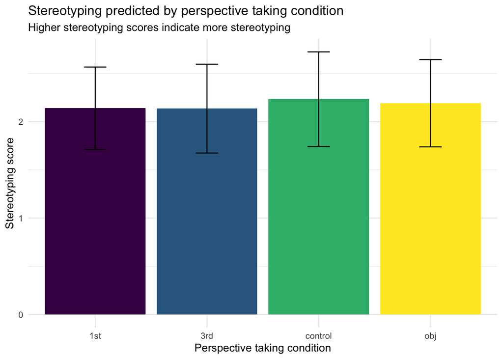

```r
ggplot(ageism_descrip, aes(pt_condition, mean, fill = pt_condition)) +
  geom_bar(stat = "identity") +
  theme_minimal() +
  scale_fill_viridis_d() +
  theme(legend.position = "none") +
  geom_errorbar(aes(ymin = mean - sd, ymax = mean + sd), width = .2,
                position = position_dodge(.9)) +
  labs(title = "Stereotyping predicted by perspective taking condition",
       subtitle = "Higher stereotyping scores indicate more stereotyping",
       x = "Perspective taking condition",
       y = "Stereotyping score")
```

# Analysis 3: Anova model predicting manipulation check by condition

```r
pt_check_model <- pov_clean %>%
  select(pt_mancheck, pt_condition, subid) %>%
  unique() %>%
  na.omit()

contrasts(pt_check_model$pt_condition) <- "contr.helmert"
contrasts(pt_check_model$pt_condition)
```

```
##         [,1] [,2] [,3]
## 1st       -1   -1   -1
## 3rd        1   -1   -1
## control    0    2   -1
## obj        0    0    3
```

```r
ptcheck_model <- lm(pt_mancheck ~ pt_condition, data = pt_check_model)
summary(ptcheck_model)
```

```
##
## Call:
## lm(formula = pt_mancheck ~ pt_condition, data = pt_check_model)
##
## Residuals:
##      Min       1Q   Median       3Q      Max
## -1.93478 -0.68367  0.06522  0.39091  2.64516
##
## Coefficients:
##               Estimate Std. Error t value Pr(>|t|)
## (Intercept)    2.64560    0.04761  55.564  < 2e-16 ***
## pt_condition1  0.12713    0.06946   1.830 0.067913 .
## pt_condition2  0.06724    0.04048   1.661 0.097462 .
## pt_condition3  0.09640    0.02537   3.800 0.000165 ***
## ---
## Signif. codes:  0 '***' 0.001 '**' 0.01 '*' 0.05 '.' 0.1 ' ' 1
##
## Residual standard error: 0.9862 on 435 degrees of freedom
## Multiple R-squared:  0.04369,    Adjusted R-squared:  0.0371
## F-statistic: 6.625 on 3 and 435 DF,  p-value: 0.0002199
```

## Plot of condition predicting manipulation check

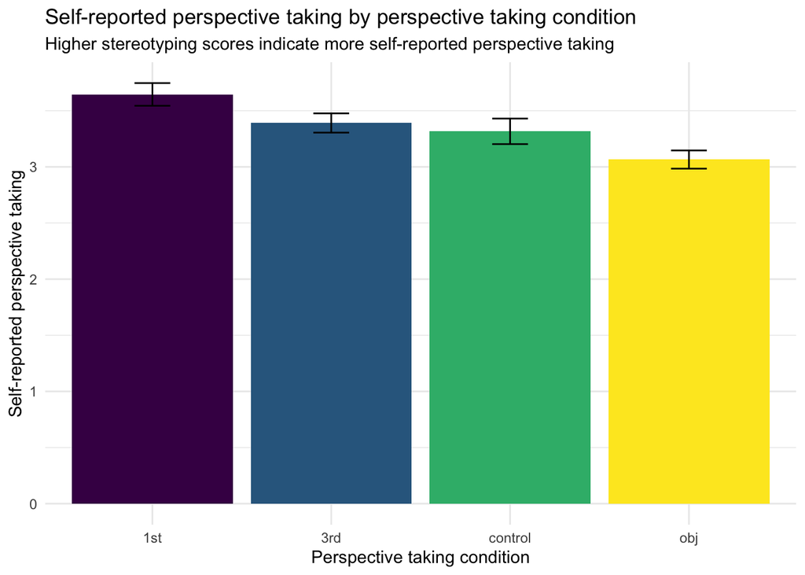

```r
pt_check_data <- pt_check_model %>%
   mutate(pt_mancheck_recode = recode(pt_mancheck,
                                 `1` = "5",
                                 `2` = "4",
                                 `3` = "3",
                                 `4` = "2",
                                 `5` = "1")) %>%
  mutate(pt_manceck_recode_num = as.numeric(pt_mancheck_recode)) %>%
  group_by(pt_condition) %>%
  summarize(mean = mean(pt_manceck_recode_num),
            sd = sd(pt_manceck_recode_num),
            se = sd(pt_manceck_recode_num)/sqrt(length(pt_manceck_recode_num)))

ggplot(pt_check_data, aes(pt_condition, mean, fill = pt_condition)) +
  geom_bar(stat = "identity") +
  theme_minimal() +
  scale_fill_viridis_d() +
  theme(legend.position = "none") +
  geom_errorbar(aes(ymin = mean - se, ymax = mean + se), width = .2,
                position = position_dodge(.9)) +
  labs(title = "Self-reported perspective taking by perspective taking condition",
       subtitle = "Higher stereotyping scores indicate more self-reported perspective taking",
       x = "Perspective taking condition",
       y = "Self-reported perspective taking")
```

The contrast that was significant was objective vs the other three (though the other two were marginal), which can be seen in this plot. Not surprising that we find less self-reported PT in the objective condition but not in the other three, though interesting we didn’t find any differences between objective and the other conditions in our outcome measures.

# Analysis 4: Model predicting difference scores for projection by condition

## Preview of the difference score data - it can have both positives and negatives, did not use absolute values

```r
diff_score_data <- pov_clean %>%
  select(subid, pt_condition, targ, self) %>%
  group_by(subid) %>%
  mutate(targ_ave = mean(targ),
         self_ave = mean(self)) %>%
  select(-c(targ, self)) %>%
  unique() %>%
  na.omit() %>%
  mutate(diff_score = self_ave-targ_ave)
diff_score_data
```

```
## # A tibble: 439 x 5
## # Groups:   subid [439]
##    subid pt_condition targ_ave self_ave diff_score
##    <dbl> <fct>           <dbl>    <dbl>      <dbl>
##  1     1 3rd              3.21     3.84     0.632
##  2     2 3rd              3.47     3.47     0
##  3     3 3rd              3.37     3.63     0.263
##  4     4 control          4.05     3.95    -0.105
##  5     5 control          3        3.32     0.316
##  6     6 obj              3.16     3.11    -0.0526
##  7     7 obj              3        3.68     0.684
##  8     8 control          3.74     4.16     0.421
##  9     9 obj              3.53     3.53     0
## 10    10 3rd              3.53     3.42    -0.105
## # … with 429 more rows
```

## Results of difference score anova

```r
diff_score_data %>%
  group_by(pt_condition) %>%
  summarize(mean = mean(diff_score),
         sd = sd(diff_score))
```

```
## # A tibble: 4 x 3
##   pt_condition   mean    sd
##   <fct>         <dbl> <dbl>
## 1 1st          0.0633 0.420
## 2 3rd          0.0860 0.433
## 3 control      0.0394 0.386
## 4 obj          0.0511 0.408
```

```r
contrasts(diff_score_data$pt_condition) <- "contr.helmert"
contrasts(diff_score_data$pt_condition)
```

```
##         [,1] [,2] [,3]
## 1st       -1   -1   -1
## 3rd        1   -1   -1
## control    0    2   -1
## obj        0    0    3
```

```r
diff_score_model <- lm(diff_score ~ pt_condition, data = diff_score_data)
summary(diff_score_model)
```

```
##
## Call:
## lm(formula = diff_score ~ pt_condition, data = diff_score_data)
##
## Residuals:
##      Min       1Q   Median       3Q      Max
## -1.27382 -0.27382  0.01321  0.26466  1.31729
##
## Coefficients:
##                Estimate Std. Error t value Pr(>|t|)
## (Intercept)    0.059972   0.019898   3.014  0.00273 **
## pt_condition1  0.011377   0.029029   0.392  0.69531
## pt_condition2 -0.011747   0.016918  -0.694  0.48783
## pt_condition3 -0.002948   0.010601  -0.278  0.78106
## ---
## Signif. codes:  0 '***' 0.001 '**' 0.01 '*' 0.05 '.' 0.1 ' ' 1
##
## Residual standard error: 0.4122 on 435 degrees of freedom
## Multiple R-squared:  0.001729,   Adjusted R-squared:  -0.005156
## F-statistic: 0.2511 on 3 and 435 DF,  p-value: 0.8606
```

Nothing is significant.